# STAT 420: Final Project

Daniil Finkel, Omar Boffil, Albert Ferguson

August 7, 2020

## Predicting UPDRS (Unified Parkinson Disease Rating Scale) from Bio-medical Voice Measurements of Individuals with Early Stage Parkinson’s Disease

## Introduction

Telehealth is a growing field. Remote medical examinations offer several benefits over conventional on-site methods:

- Secure and confidential: patients do not need to be seen at a specialists office
- Convenience: patients can attend appointments from comfort of their own home
- Increased access: patients are no longer restricted to geographically local physicians
- Reduced cancellation: patients more consistently attend, more closely monitored
- Many others

*Telemonitoring* is one form of telehealth in which information technology is used to monitor patients at a distance. The feasibility of such automated approaches calls for robust diagnoses to justify widespread adoption. This project aims to contribute to that goal.

Parkinson’s disease is a neurodegenerative disease characterized by stiffness and shakiness in motor functions of affected individuals. The disease tends to become more severe over time.

A research collaboration between the University of Oxford, 10 medical centers in the US, and Intel Corporation organized a 6-month trial, recording a range of bio-medical voice measurements from 42 people with early-stage Parkinson’s disease. The effort produced a dataset with the following characteristics:

- 5875 observations
- 22 attributes:
  - subject# - Integer that uniquely identifies each subject
  - age - Subject age
  - sex - Subject gender ‘0’ - male, ‘1’ - female
  - test_time - Time since recruitment into the trial. The integer part is the number of days since recruitment.
  - motor_UPDRS - Clinician’s motor UPDRS score, linearly interpolated
  - total_UPDRS - Clinician’s total UPDRS score, linearly interpolated
  - Jitter(%), Jitter(Abs), Jitter:RAP, Jitter:PPQ5, Jitter:DDP
    - Several measures of variation in fundamental frequency
  - Shimmer, Shimmer(dB), Shimmer:APQ3, Shimmer:APQ5, Shimmer:APQ11, Shimmer:DDA
    - Several measures of variation in amplitude
  - NHR, HNR - Two measures of ratio of noise to tonal components in the voice
  - RPDE - A nonlinear dynamical complexity measure
  - DFA - Signal fractal scaling exponent
  - PPE - A nonlinear measure of fundamental frequency variation

The dataset and a description of the aims of its collection are provided here: https://archive.ics.uci.edu/ml/datasets/Parkinsons+Telemonitoring

A key attribute in the above set is `total_UPDRS`. The Unified Parkinson’s Disease Rating Scale (UPDRS) is used to measure the degree of Parkinson’s in an individual - a higher score indicating a more severe case.

This project aims to develop a model to predict `total_UPDRS` using the remaining attributes, effectively developing a model to predict the degree to which an individual is affected by Parkinson’s disease.

## Methods

### Exploratory Phase

Examining the dataset revealed it was already very clean. There were no empty values or obvious typos that needed to be fixed. However, looking over the column names and underlying data revealed some modifications needed to be made before modeling.

```r
library(readr)
parkins = read_csv("parkinsons_updrs.csv")
```

The `subject#` column is a unique identifier for each individual. Because our aim is to develop a model that is generally applicable, and not fit to specific individuals of this 42-person study, we chose to remove it.

```r
parkins = subset(parkins, select = -c(`subject#`))
```

#### Variable Examination

An evaluation of the distributions of all of the predictors in the dataset can be found in Figure 1.

The distributions can be generated with the following code:

```r
library(purrr)
library(tidyr)
library(ggplot2)

parkins %>%
  gather() %>%
  ggplot(aes(value)) +
    facet_wrap(~ key, scales = "free") +
    geom_histogram()
```

These distributions show some familiar shapes. `HNR` looks to most closely resemble a normal distribution amongst the set of predictors, with `RPDE` also appearing somewhat normal. These two metrics show a single, symmetric, bell-shaped curve. Several columns, including all Jitter metrics, all Shimmer metrics, and `NHR` show distributions with heavy right tails.

We also see that the individuals range in `age` from about 35-90, with the majority of them falling between 55-80 years old. This is worth noting as it implies any model built likely won’t generalize well outside those age ranges.

We can also create box plots for these columns, to see a more quantified breakdown of the distribution of values within each. Figures 2-5 show the results of these plots.

The box plots were generated with the following code:

```r
library(reshape)
library(ggplot2)

show_box_plot = function(frame) {
  meltData = melt(frame)
  p <- ggplot(meltData, aes(variable, value))
  p + geom_boxplot() + facet_wrap(~variable, scale="free")
}

show_box_plot(
  data.frame(
    age = parkins$`age`,
    test_time = parkins$`test_time`,
    motor_UPDRS = parkins$`motor_UPDRS`,
    total_UPDRS = parkins$`total_UPDRS`,
      DFA = parkins$`DFA`
  )
)

show_box_plot(
  data.frame(
    Jitter_Abs = parkins$`Jitter(Abs)`,
    Jitter_RAP = parkins$`Jitter:RAP`,
    Jitter_PPQ5 = parkins$`Jitter:PPQ5`,
    Jitter_DDP = parkins$`Jitter:DDP`,
    Shimmer = parkins$`Shimmer`
  )
)

show_box_plot(
  data.frame(
      Shimmer_dB = parkins$`Shimmer(dB)`,
    Shimmer_APQ3 = parkins$`Shimmer:APQ3`,
    Shimmer_APQ5 = parkins$`Shimmer:APQ5`,
    Shimmer_APQ11 = parkins$`Shimmer:APQ11`,
    Shimmer_DDA = parkins$`Shimmer:DDA`
  )
)

show_box_plot(
  data.frame(
    NHR = parkins$`NHR`,
    HNR = parkins$`HNR`,
    RPDE = parkins$`RPDE`,
    Jitter_Percent = parkins$`Jitter(%)`,
    PPE = parkins$`PPE`
  )
)
```

Because the `Jitter` and `Shimmer` variables contain many variations, we assume they share fundamental characteristics and we suspect there will be some collinearity among them. In addition, since the `motor_UPDRS` score is a component in the calculation of the `total_UPDRS` score, we also expect these columns to be highly correlated with one another. Figures 6-9 show scatterplots of all the columns against our response, `total_UPDRS`, as well as with columns where we suspect collinearity. Because collinearity can increase the variance of coefficient estimates, making estimates very sensitive to minor changes in our models, we will seek to eliminate collinearity from the set of predictors. By removing collinear relationships between our predictors, we presume we will be building more robust models.

We can generate the scatterplots using the following code:

```r
library(GGally)
ggpairs(columns = c(5, 4, 1, 2, 3), data=parkins)
ggpairs(columns = c(5, 17, 18, 19, 20, 21), data=parkins)
ggpairs(columns = c(5, 6, 7, 8, 9, 10), data=parkins)
ggpairs(columns = c(5, 11, 12, 13, 14, 15, 16), data=parkins)
```

Another method of measuring collinearity is through the variance inflation factors (VIF) of the individual predictor columns with each other, where values larger than $5$ imply collinearity. An interesting property of VIF is that if two columns are collinear, their VIF values will be very large. However, if one of those columns is removed and the VIF is recalculated, the leftover column’s VIF value will drop significantly if there are no other columns collinear with it. With this, we can take an iterative approach and repeatedly remove the column with the largest VIF until the resulting columns all have values less than $5$.

We have added a function to address issues with collinearity below:

```r
library(faraway)

# Drop columns that have a vif > 5, starting with highest first
fix_vif = function (data) {
  newData = data
  max_vif = max(faraway::vif(newData))
  while (max_vif > 5) {
    newData = subset(newData,
                     select = c(setdiff(names(newData), names(which.max(faraway::vif(newData))))))
    max_vif = max(faraway::vif(newData))
  }
  newData
}
```

Evaluating our measures of collinearity, `motor_UPDRS` was found to be highly collinear with `total_UPDRS`, as expected. It makes sense that knowledge of a subject’s `motor_UPDRS` score would be incredibly informative for predicting their total score, but a predictive model likely wouldn’t be needed if that information was already available, so we chose to remove it from our model building process.

```r
# Remove the motor_UDPRS column from the dataset
parkins = subset(parkins, select = -c(motor_UPDRS))
```

Evaluating the other columns did not show any strong linear correlations with `total_UPDRS`, unfortunately, so there was no early indication that an additive model would be enough. On the other hand, there also were no obvious polynomial relationships, so we felt confident we would not need to apply any polynomial transformations. Interactions were still a strong possibility that couldn’t be ignored. We tried several tranformations of both the response and predictors, including `log`, `sin/cos`, and low order polynomials, but none of these attempts resulted in models with acceptable test RMSE values.

### Model Building Phase

To get a general idea of how effective the predictors would be, we used all the rows and all the columns to train fully additive and interaction models.

```r
additive_fit = lm(total_UPDRS ~ . , data = parkins)
interaction_fit = lm(total_UPDRS ~ (.)^2 , data = parkins)
```

- The fully additive model created a poorly fit model with an adjusted $R^2$ of `0.1738673`.
- The interaction model gave a slight improvement, with an adjusted $R^2$ of `0.3198572`.

These poor initial results didn’t inspire much confidence, but there were still many improvements that could be applied. Before beginning the model building process in earnest, a suite of helper functions were created in A1 to provide a standard method of evaluating our models. Metrics that were calculated include:

- Breusch-Pagan test
- Shapiro-Wilk test
- Root Mean Squared Error (RMSE) on training set
- RMSE on test set
- Mean Absolute Error (MAE) on test set
- Leave One Out Cross Validation (LOOCV) RMSE
- Adjusted $R^2$
- Number of Predictors

It also contains functions for removing influential points, a process found to reduce the likelihood of overfitting among our models, as well as functions to create “Fitted vs Residual”, “Q-Q”, and “Predicted vs Actual” plots.

After a significant amount of trial and error, a simulation was created to randomly split the dataset into a training ($80$%) and test ($20$%) set $10$ times, training and evaluating models we found to be interesting. These models were:

- A full additive model
- A full additive model, after collinear columns removed by VIF
- A full interaction model
- A full interaction model, after collinear columns removed by VIF
- Backward stepwise elimination by **AIC**, of full interaction model, after collinear columns removed by VIF, and influential points removed
- Backward stepwise elimination by **BIC**, of full interaction model, after collinear columns removed by VIF, and influential points removed
- An “overfit” model that was found to produce relatively high adjusted $R^2$

The average evaluation metrics for each of these models across all $10$ simulations are shown in Table 1.

The code used to develop and gather statistics for our models is included below:

```r
set.seed(420)
num_sims = 10
num_metrics = 8

additive_evals = rep(list(rep(0, num_sims)), num_metrics)
interaction_evals = rep(list(rep(0, num_sims)), num_metrics)
additive_vif_evals = rep(list(rep(0, num_sims)), num_metrics)
interaction_vif_evals = rep(list(rep(0, num_sims)), num_metrics)
overfit_evals = rep(list(rep(0, num_sims)), num_metrics)
back_aic_evals = rep(list(rep(0, num_sims)), num_metrics)
back_bic_evals = rep(list(rep(0, num_sims)), num_metrics)

for (i in 1:num_sims) {
  # create a new train/test split
  park_trn_idx  = sample(nrow(parkins), size = trunc(0.80 * nrow(parkins)))
  park_trn_data = parkins[park_trn_idx, ]
  park_tst_data = parkins[-park_trn_idx, ]

  # train full additive model
  add_fit = lm(total_UPDRS ~ . , data = park_trn_data)
  add_eval = eval_model(add_fit, park_tst_data)

  # train full interaction model
  int_fit = lm(total_UPDRS ~ .^2 , data = park_trn_data)
  int_eval = eval_model(int_fit, park_tst_data)

  # use VIF to remove collinear columns
  vif_rem_park_trn_data = fix_vif(park_trn_data)

  # train additive model with columns removed by VIF
  add_vif_fit = lm(total_UPDRS ~ . , data = vif_rem_park_trn_data)
  add_vif_eval = eval_model(add_vif_fit, park_tst_data)

  # train interaction model with columns removed by VIF
  int_vif_fit = lm(total_UPDRS ~ .^2 , data = vif_rem_park_trn_data)
  int_vif_eval = eval_model(int_vif_fit, park_tst_data)


  # model that "overfit"
  overfit_init_fit = lm(total_UPDRS ~ ( . - `Jitter(%)` - `Jitter:RAP` - `Shimmer:APQ3`) ^ 2,
                   data = park_trn_data)
  overfit_fit = lm(total_UPDRS ~ ( . - `Jitter(%)` - `Jitter:RAP` - `Shimmer:APQ3`) ^ 2,
              data = park_trn_data, subset = non_influential_filter(overfit_init_fit))
  overfit_eval = eval_model(overfit_fit, park_tst_data)

  # Removing Influential Points, Interaction model, and step back AIC
  back_aic_fit = step(lm(total_UPDRS ~ .^2 , data = vif_rem_park_trn_data,
                         subset = non_influential_filter(int_vif_fit)), direction = 'backward', trace = 0)
  back_aic_eval = eval_model(back_aic_fit, park_tst_data)

  # Removing Influential Points, Interaction model, and step back BIC
  n = length(resid(int_vif_fit))
  back_bic_fit = step(lm(total_UPDRS ~ .^2 , data = vif_rem_park_trn_data,
                         subset = non_influential_filter(int_vif_fit)),
                      direction = 'backward', trace = 0, k = log(n))
  back_bic_eval = eval_model(back_bic_fit, park_tst_data)

  for (j in 1:num_metrics) {
    additive_evals[[j]][i] = add_eval[j]
    interaction_evals[[j]][i] = int_eval[j]
    additive_vif_evals[[j]][i] = add_vif_eval[j]
    interaction_vif_evals[[j]][i] = int_vif_eval[j]
    overfit_evals[[j]][i] = overfit_eval[j]
    back_aic_evals[[j]][i] = back_aic_eval[j]
    back_bic_evals[[j]][i] = back_bic_eval[j]
  }

}
```

## Results

#### Column Distributions

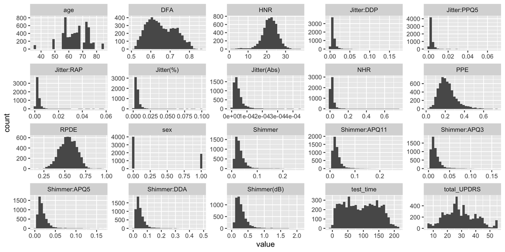

Figure 1: Column Distributions

#### Box Plots

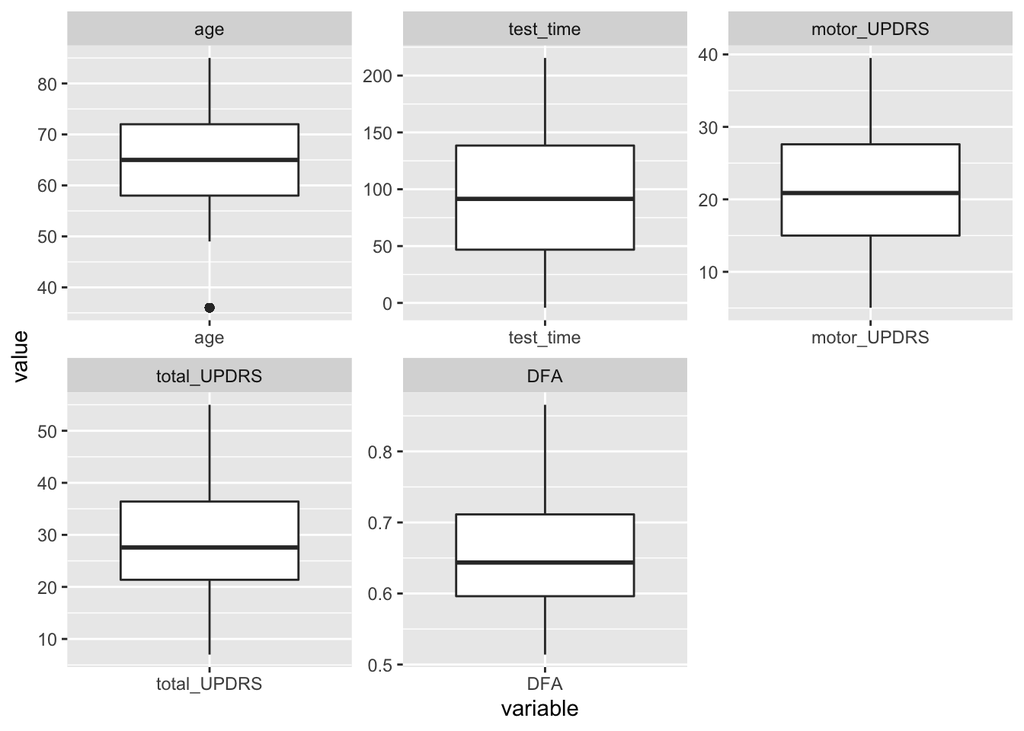

Figure 2: Box plots of age, test_time, motor_UPDRS, total_UPDRS, and DFA

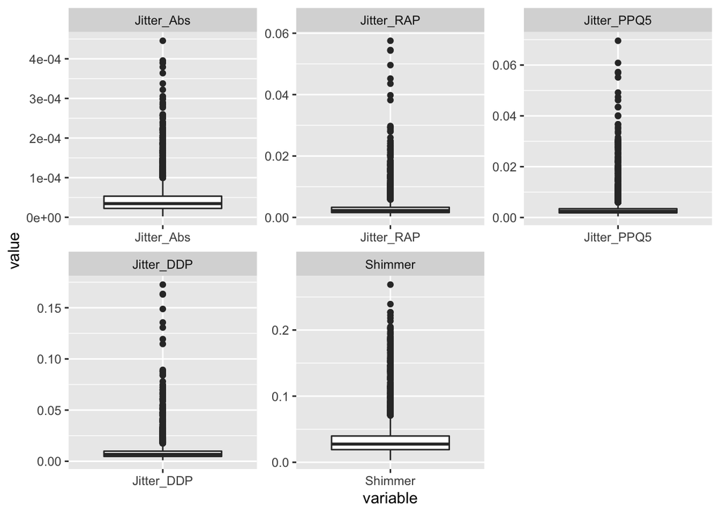

Figure 3: Box plots of Jitter_Abs, Jitter_RAP, Jitter_PPQ5, Jitter_DDP, and Shimmer

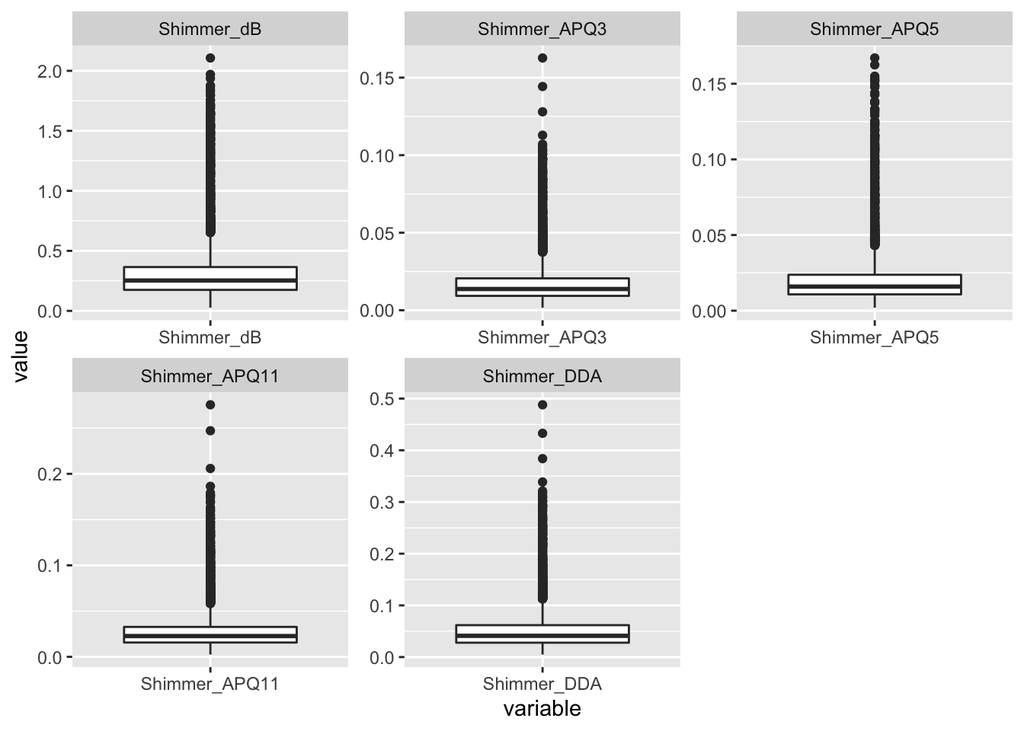

Figure 4: Box plots of Shimmer_dB, Shimmer_APQ3, Shimmer_APQ5, Shimmer_APQ11, and Shimmer_DDA

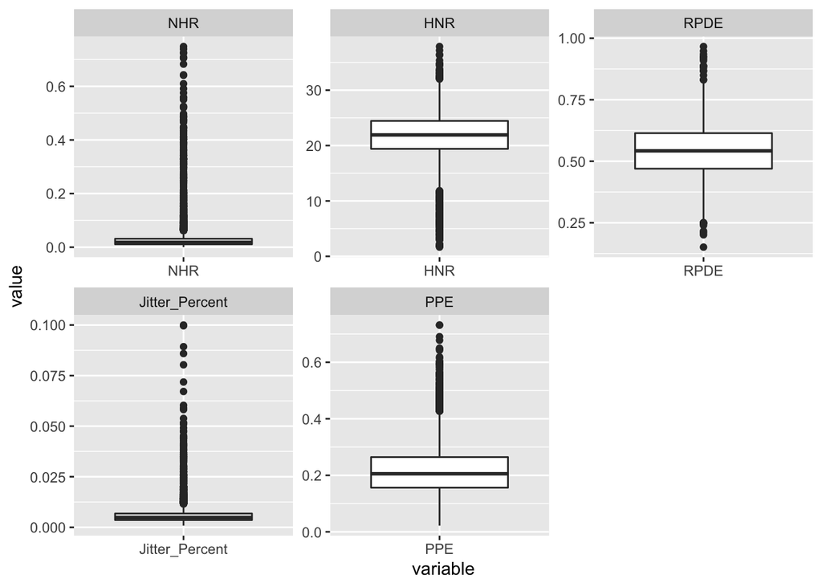

Figure 5: Box plots of NHR, HNR, RPDE, Jitter_Percent, and PPE

#### Colinearity scatterplot matrix

[figure not shown]

Figure 6: Collinearity between total_UPDRS, motor_UPDRS, sex, test_time, and age

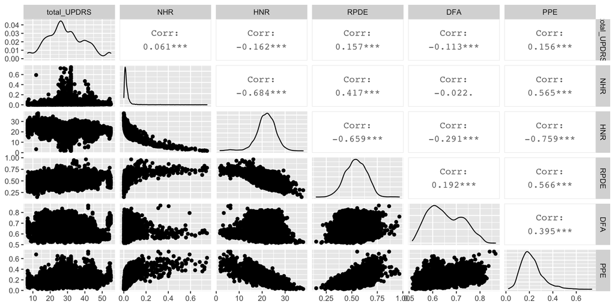

Figure 7: Collinearity between total_UPDRS, NHR, HNR, RPDE, DFA, and PPE

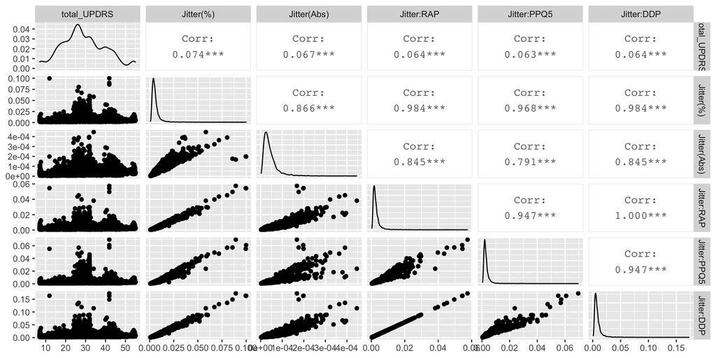

Figure 8: Collinearity between total_UPDRS, Jitter(%), Jitter(Abs), Jitter:RAP, Jitter:PPQ5, and Jitter:DDP

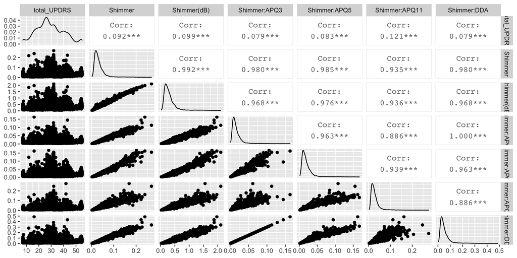

Figure 9: Collinearity between total_UPDRS, Shimmer, Shimmer(db), Shimmer:APQ3, Shimmer:APQ5, Shimmer:APQ11, and Shimmer:DDA

#### Comparison of models, with metrics averaged over 10 data splits

Table 1: Comparison of average model metrics

| model | rmse_loocv | rmse_trn | rmse_tst | mae_tst | adj_r2 | num_pred |
| --- | --- | --- | --- | --- | --- | --- |
| additive_full | 9.746 | 9.701 | 9.763 | 8.065 | 0.177 | 20.0 |
| additive_vif | 9.818 | 9.797 | 9.819 | 8.101 | 0.162 | 10.9 |
| interaction | 9.870 | 8.634 | 10.312 | 7.512 | 0.323 | 191.0 |
| interaction_vif | 9.502 | 9.369 | 9.467 | 7.727 | 0.226 | 55.0 |
| overfit_model | 8.627 | 8.321 | 12.158 | 7.744 | 0.375 | 137.0 |
| back_aic_interaction | 8.995 | 8.930 | 9.926 | 7.794 | 0.269 | 40.2 |
| back_bic_interaction | 9.021 | 8.973 | 9.836 | 7.793 | 0.264 | 29.7 |

#### Fitted vs Residuals and Q-Q Plots

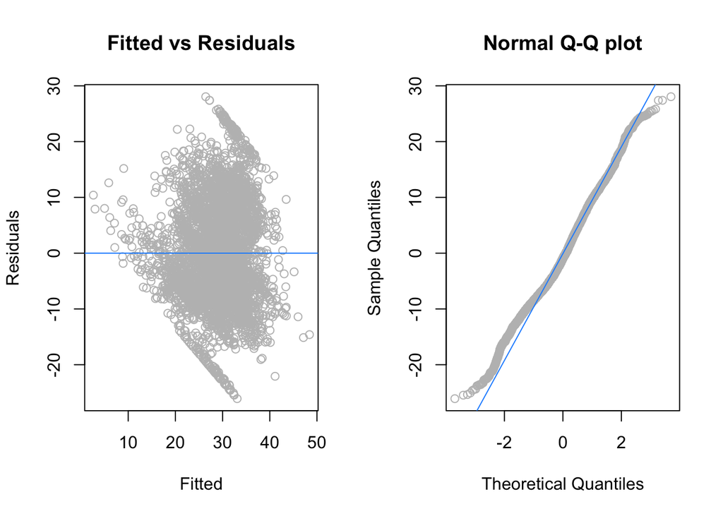

Figure 10: Fitted vs Residuals and Q-Q plot of the best model

#### Predicted vs Actual plot

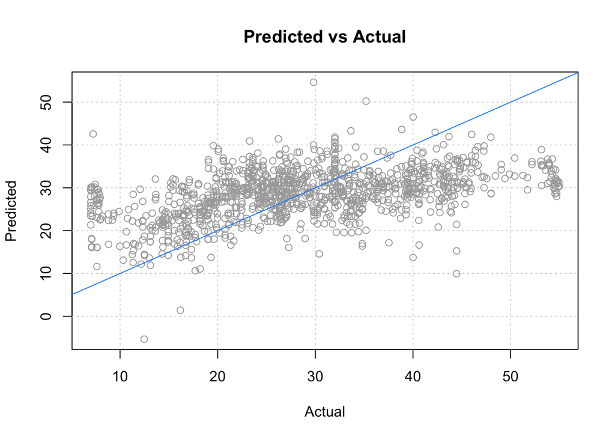

Figure 11: Predicted vs Actuals of best model evaluated on test data

## Discussion

#### Model Training Results

Evaluating Table 1, shows the averaged metrics computed across all the models. Even though the Breusch-Pagan test statistic and Shapiro-Wilk test statistic were collected for each model, they were always very close to zero. None of our various attempts were able to bring their values above `0.05`, or even `0.01`. Because of this, they were not included in the Table.

In order to determine what our “best” model was, we couldn’t look at only a single metric. This is best shown with the “overfit” model. Looking at just its LOOCV RMSE, or just its adjusted $R^2$, would make it seem like the best model overall. However, looking at the RMSE on the test set returns the worst results compared to all the other models. Very good training metrics with very bad test metrics are the hallmark for an overfit model. If we were to weigh any individual metric more than the others, test RMSE would probably be the most informative for determining the best predictive model. A low test RMSE would imply a model that is able to generalize to new data, which is what one would want from a predictive model.

Though Table 1 doesn’t include models where the only processing step applied was removing the influential points, doing so was found to improve our test set RMSEs across the board. Those results “influenced” us to remove the influential points when training our best `back_aic_interaction` and `back_bic_interaction` models.

#### Influential points

Removing influential points was key in the selection of our model. Using Cook’s Distance, and the heuristic discussed in class, an “influential” point being a point which has Cook’s Distance more than 4 divided by the length of the dataset, we found on average about 4% of training data was influential for the models we fit. We were able to improve our models and prevent overfitting by removing these influential points.

#### Checking linearity assumptions of the model

Often, the assumptions of linear regression are stated as<sup>[1](http://daviddalpiaz.github.io/appliedstats/model-diagnostics.html)</sup>,

- Linearity - the response can be written as a linear combination of the predictors
- Independence - the errors are independent
- Normality - the distribution of the errors should follow a normal distribution
- Equal Variance - the error variance is the same at any set of predictor values

We can verify these assumptions using several formal tests and by examining plots using data from our models.

We can assess linearity by examining the fitted vs. residuals plot. In order for linearity to be satisfied, the mean of the fitted vs. residuals plot should be 0 everywhere. We can see this is not the case, and so we conclude there are linearity issues with our model for this data.

To assess equal variance, we can look at the fitted vs. residuals plot, and also consider the results of the Breusch-Pagan test. The fitted vs. residuals plot does not show a roughly equal spread about the mean at all fitted values. This causes us to suspect there are issues with equal variance in our model. The Breusch-Pagan test confirms this suspicion. The small p-value from our Breusch-Pagan test runs indicates that the null hypothesis of $H_0$: homoscedasticity should be rejected, causing us to conclude there are issues with this metric.

#### Discussion of Predicted vs. Actual Plot

The predicted vs. actual plot shows the effect of the model selected and compares it against the test dataset. We clearly can see that we have room for improvement because the point is not perfectly following the regression line. Also, we can find in our model that we have predictions out of the chart for values less than ten, and others around the 30 range are far from the actual values or overestimating it, which makes us suspicious of how well this model can be useful for predictions. Also, we noticed that the majority of the values after 30 underestimate the actual values, especially in values over 50. On average, this was the best model we found in our research, but the Predicted vs. Actual plot confirms that this model is not the best when we want to make predictions.

## Appendix

#### A1: Helper Functions

Below, we have included functions utilized throughout this project. We have included functions to perform various statistical tests and evaluate the models developed throughout the report.

```
# Calculates the Root Mean Squared Error (RMSE) of a model evaluated on a dataset
calc_rmse = function(model, tst_data){
  sqrt(mean((predict(model, tst_data) - tst_data$total_UPDRS) ^ 2))
}

# Calculates the Mean Absolute Error (MAE) of a model evaluated on a dataset
calc_mae = function(model, tst_data){
  mean(abs(predict(model, tst_data) - tst_data$total_UPDRS))
}

# Performs the Breusch-Pagan test on a model
get_bp = function(model) {
  unname(bptest(model)$p.value)
}

# Performs the Shapiro-Wilk test on a model
get_sw = function(model) {
  unname(shapiro.test(resid(model))$p.value)
}

# Extract the number of coefficients of a model
get_num_params = function(model) {
  length(coef(model))
}

# Calculates the Leave One Out Cross Validation (LOOCV) RMSE of a model
get_loocv_rmse = function(model) {
  sqrt(mean((resid(model) / (1 - hatvalues(model))) ^ 2))
}

# Calculates the Adjusted R^2 of a model
get_adj_r2 = function(model) {
  summary(model)$adj.r.squared
}

# Performs all the above evaluations on a model and dataset, and returns a list of results
eval_model = function(model, tst_data){
  list(b_pagan = get_bp(model),
       shap_wilk = get_sw(model),
       rmse_loocv = get_loocv_rmse(model),
```

[output cut: 17 more lines]

```
# Creates a filter of all non-influential points of a model
non_influential_filter = function(model){
  cooks.distance(model) <= (4 / length(cooks.distance(model)))
}

# Creates a plot of Predicted vs Actuals
plot_pva = function(predicted, actual){
  plot(actual, predicted,
     col = "darkgrey",
     xlab = "Actual",
     ylab = "Predicted",
     main = "Predicted vs Actual")
  grid()
  abline(0, 1, col = "dodgerblue")
}
```

#### Names of Team DOT members

- Daniilf2 - Daniil Finkel
- Oboffil2 - Omar Boffil
- Albertf2 - Albert Ferguson